# Explanatory_analysis_for_Fordgobike_dataset

```python
#import nessery libiraies
import numpy as np
import pandas as pd
import matplotlib.pyplot as plt
import seaborn as sb
from scipy import stats
#To suppress warningsin visualizations
import warnings
warnings.filterwarnings('ignore')

%matplotlib inline
trips = pd.read_csv('new_trips.csv')
```

## Explantory analysis

#### In these section we need to collect some question that we need to answer it and start to answer it here 1-what is the most stations is have problem for availability of bike ? 2-Why there is afew number of female users?

### 1-what is the most stations is have problem for availability of bike ?

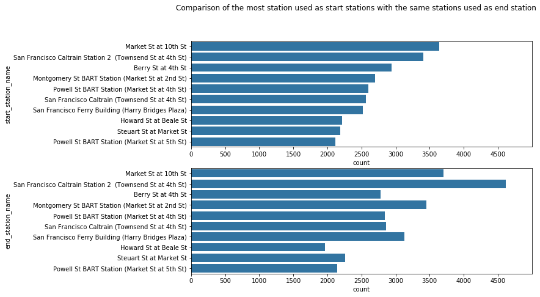

```python
# Here we will use count plot to get to compare the most station used as start stations with the same stations used as end station
# Maximize the size of graph to be more clear
plt.figure(figsize = [10, 7])

#apply one color there is no need to more than one
base_color = sb.color_palette()[0]

#make the graphs in one column to be easy to compare and show the difference
plt.subplot(2, 1, 1)
# Get the indexes of beggist 10 statins in the Series
n = 10
start_staion_order = trips['start_station_name'].value_counts()[:n].index

# Plot the bar chart in the decreasing order of the frequency of the `start_station`
sb.countplot(data=trips, y='start_station_name', color=base_color, order=start_staion_order);

#unit the limits and interval in two graph
plt.xlim(right=5000);
plt.xticks(np.arange(0, 5000, 500));

plt.subplot(2, 1, 2)
# Plot the bar chart in the decreasing order of the frequency of the `end_station_name`
sb.countplot(data=trips, y='end_station_name', color=base_color, order=start_staion_order);

#unit the limits and interval in two graph
plt.xlim(right=5000);
plt.xticks(np.arange(0, 5000, 500));

plt.suptitle('Comparison of the most station used as start stations with the same stations used as end station', y = 1);
```

Results:  
1-the san francisco caltrian station2,Montogomery St BART Station and san francisco ferry building have high availability for bikes because it used as distination point more than start poin  
2-Powell St BART Station and san francisco Caltrain have high availability of bikes but not too much  
3-Berry ST at 4th St and Howard ST at Beale ST is really have aproblem in availbility of bikes because there is abig difference in using of them.they are used as start more than distination point .I think they are need to transfer bikes to them from station that have high availability

**For inverse condition most destination sation but not start station**

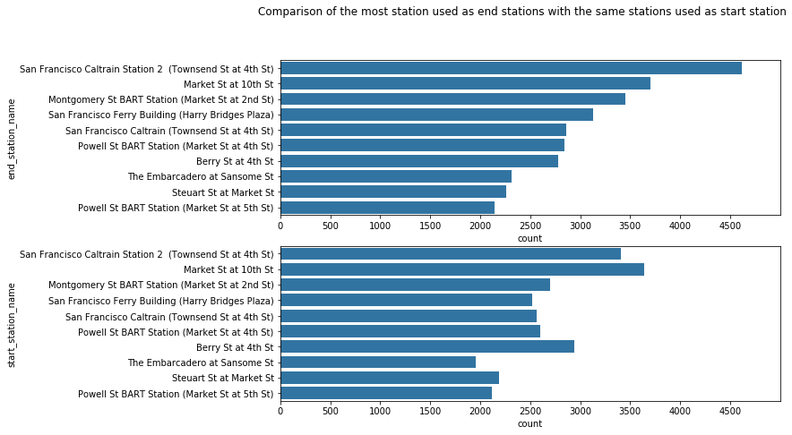

```python
# Here we will use count plot to get to compare the most station used as end stations with when the same stations used as end stations
# Maximize the size of graph to be more clear
plt.figure(figsize = [10, 7])

#apply one color there is no need to more than one
base_color = sb.color_palette()[0]

#make the graphs in one column to be easy to compare and show the difference
plt.subplot(2, 1, 1)
# Get the indexes of beggist 10 statins in the Series
n = 10
end_staion_order = trips['end_station_name'].value_counts()[:n].index

# Plot the bar chart in the decreasing order of the frequency of the `end_station`
sb.countplot(data=trips, y='end_station_name', color=base_color, order=end_staion_order);

#unit the limits and interval in two graph
plt.xlim(right=5000);
plt.xticks(np.arange(0, 5000, 500));

plt.subplot(2, 1, 2)
# Plot the bar chart in the decreasing order of the frequency of the `start_station_name'
sb.countplot(data=trips, y='start_station_name', color=base_color, order=end_staion_order);

#unit the limits and interval in two graph
plt.xlim(right=5000);
plt.xticks(np.arange(0, 5000, 500));

plt.suptitle('Comparison of the most station used as end stations with the same stations used as start station', y = 1);
```

### 2-Why there is afew number of female users?

**We can answer these question when we get relation of gender with age , speed and distance**

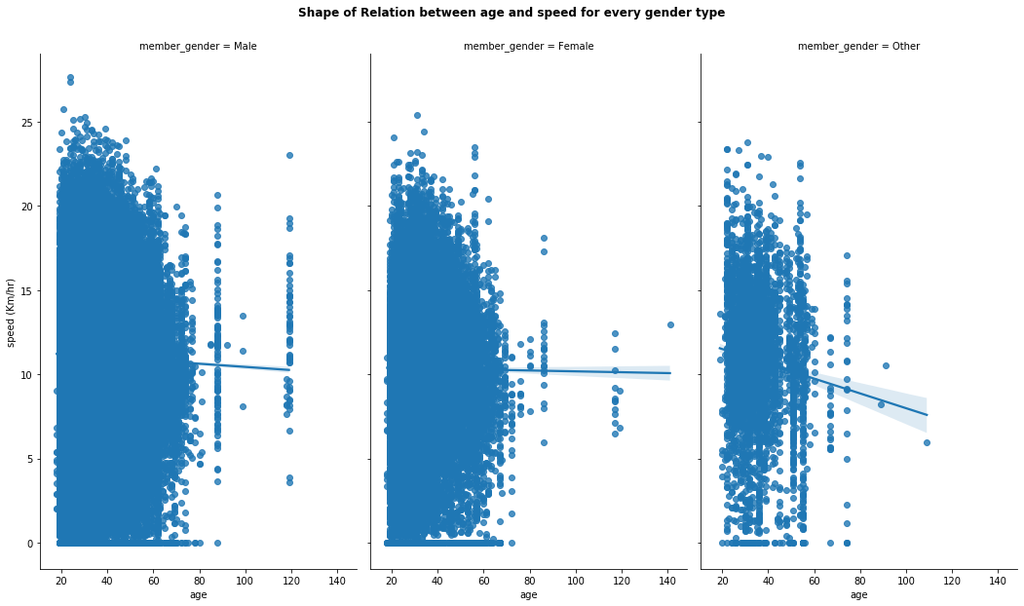

```python
#Here we use the facegrid to show the relation between speed and age for every gender type
g = sb.FacetGrid(data = trips, col = 'member_gender',margin_titles = True,height = 8.27,aspect = (14.7/3)/(8.27));
g.map(sb.regplot, 'age', 'speed');
g.set_axis_labels(x_var="age", y_var="speed (Km/hr)");
plt.suptitle('Shape of Relation between age and speed for every gender type', y = 1.04,fontsize = 14 , weight = "bold");
```

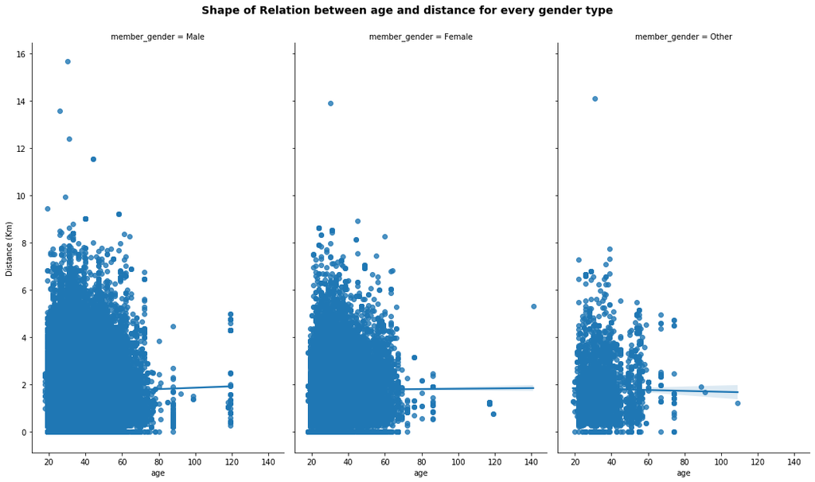

```python
#Here we use the facegrid to show the relation between distance and age for every gender type
g = sb.FacetGrid(data = trips, col = 'member_gender',margin_titles = True,height = 8.27,aspect = (14.7/3)/(8.27))
g.map(sb.regplot, 'age', 'distance');
g.set_axis_labels(x_var="age", y_var="Distance (Km)");
plt.suptitle('Shape of Relation between age and distance for every gender type', y = 1.04,fontsize = 14 , weight = "bold");
```

**The relation between age,distannce and speed in gender types i almost the same but there is alittel difference in speed the men is more in speed and for sure as result they take a less duration so it may a reason for some female that the trip take a lot of time and also we need more data to be able to get strong reasons for why there is afew number of female gender in comparing to male users**

```python
!jupyter nbconvert Explanatory_analysis_for_Fordgobike_dataset.ipynb --to slides --post serve  --no-input --no-prompt
```